# Communicate Data Finding Slide-Deck : Ford GoBike System Data

## By : Patel Meet

## Investigation Overview

> What are the features affecting trip duration the most ( weather , user type )

## Dataset Overview

> This data set includes information about individual rides made in a bike-sharing system covering the greater San Francisco Bay area.

```python
# Initialization

import numpy as np
import pandas as pd
import matplotlib.pyplot as plt

import seaborn as sb
import os
%matplotlib inline

# Suppressing warnings from the final output
import warnings
warnings.simplefilter("ignore")
```

## (Visualization 1)

> Question 1 : What is the distribution of trip duration?

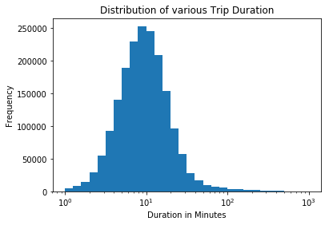

```python
# Let's plot the distribution of trip duration.
# change the trip duration unit from second to min
df_bike_copy['duration_min'] = df_bike_copy['duration_sec'] / 60
df_bike_copy.drop('duration_sec' , axis = 1 , inplace = True)

binedges = 10**np.arange(0 , 3+0.1 , 0.1)
ticks =  [ 0.1 , 0.3 , 1 , 3, 10, 30, 100, 300]
labels = ['{}'.format(v) for v in ticks]
plt.hist(data = df_bike_copy , x = 'duration_min' , bins = binedges);
plt.xticks(ticks,labels);
plt.title('Distribution of various Trip Duration')
plt.xlabel('Duration in Minutes');
plt.ylabel('Frequency')
plt.xscale('log');
```

> Conclusion 1 : As we can easily interpret from the above plot, a majority of folks have a tendency towards using the bikes for a short-time durational trips (around 10 mins).

## (Visualization 2)

> Question 2. Does weather impact the trip duration ?

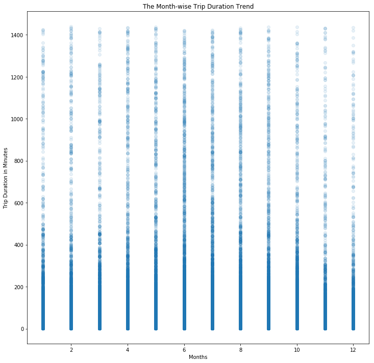

```python
df_bike_copy['month_start'] = pd.DatetimeIndex(df_bike_copy['start_time']).month
# We can check the trip duration over changes over each month.
plt.figure(figsize = [12,12]) # Makes the figure enlarged for better visualization
plt.scatter(data = df_bike_copy , x = 'month_start' , y = 'duration_min' , alpha = 0.1 )
plt.title('The Month-wise Trip Duration Trend')
plt.xlabel('Months')
plt.ylabel('Trip Duration in Minutes')
```

> Question 3. Will weather(with regards season) depict a more obvious affect on the trip duration ?

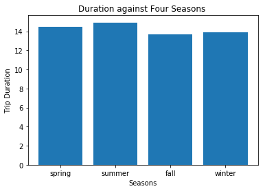

```python
# We categorize our 4 seasons categories
spring = df_bike_copy.query('month_start in ["3" , "4" , "5"]' ).duration_min.mean ()
summer = df_bike_copy.query('month_start in ["6" , "7" , "8"] ').duration_min.mean()
fall = df_bike_copy.query('month_start in ["9" , "10" , "11"] ').duration_min.mean()
winter = df_bike_copy.query('month_start in ["12" , "1" , "2"]' ).duration_min.mean()



plt.bar(['spring','summer','fall','winter'],[spring , summer , fall , winter] )
plt.title('Duration against Four Seasons ')
plt.xlabel('Seasons')
plt.ylabel('Trip Duration');
```

> Conclusion 2 : Thus, we may conclude that the weather does affect the trip duration, but the affect is very limited. Summer and Spring have relatively higher trip duration. Fall turns to have the lowest trip duration. After further investigation, I found that in the Fall of 2018 there was a wildfire in California, which caused the worst air quality in San Francisco. It is very likely that people had a tendency to do less outdoor activities due to the pool air quality.

## (Visualization 3)

Question 4 : What is the impact or dependency of the above insights on whether a user is a subscriber or a customer?

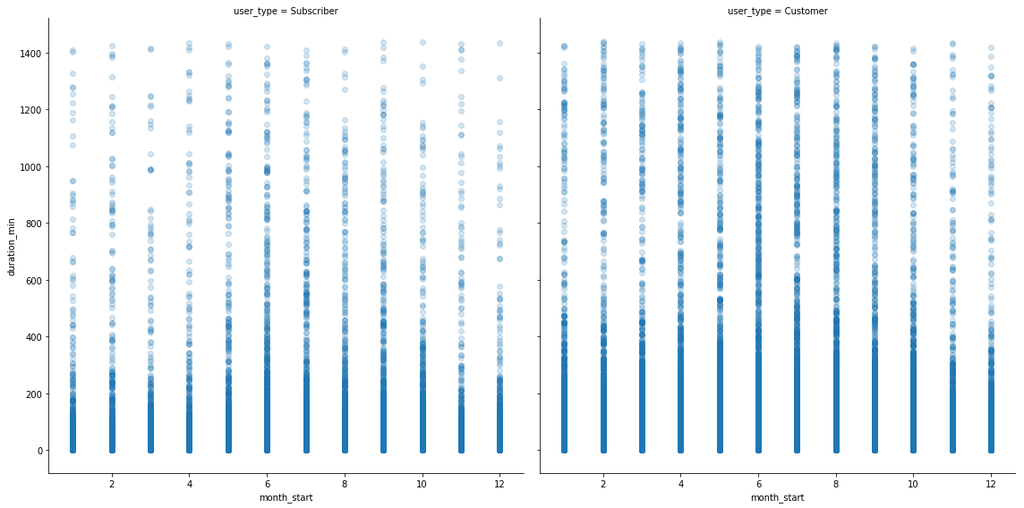

```python
m = sb.FacetGrid(data =  df_bike_copy, col = 'user_type', size = 8, col_wrap = 2)
m.map(sb.regplot, 'month_start', 'duration_min', y_jitter = 0.04, fit_reg = False,scatter_kws = {'alpha' : 1/5});
```

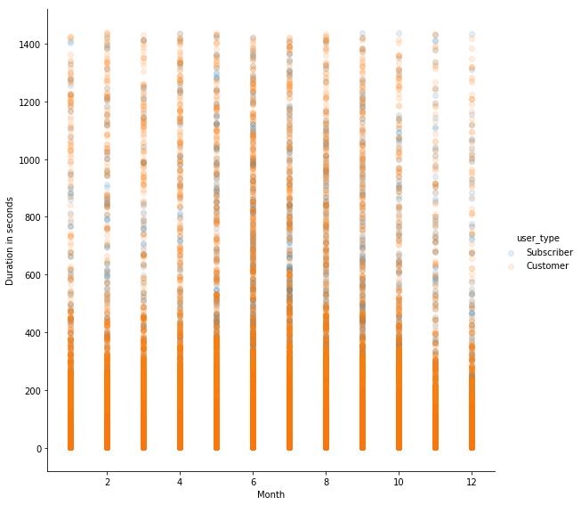

```python
month = sb.FacetGrid(data = df_bike_copy, hue = 'user_type', hue_order = ['Subscriber','Customer'], size = 8)
month.map(plt.scatter, 'month_start','duration_min', alpha = 1/8)
month.add_legend()
plt.xlabel('Month')
plt.ylabel('Duration in seconds');
```